# 99 - Reference

```r
library(caracas)
```

## Quick start

```r
x <- symbol('x')
as.character(x)
```

```
#> [1] "x"
```

```r
x
```

```
#> c: x
```

```r
as_expr(x)
```

```
#> expression(x)
```

```r
2*x
```

```
#> c: 2⋅x
```

```r
y <- symbol('y')
sqrt(3*x^y)
```

```
#> c:       ____
#>         ╱  y
#>    √3⋅╲╱  x
```

```r
z <- cos(x)^2 + sin(x)^2
z
```

```
#> c:    2         2
#>    sin (x) + cos (x)
```

```r
simplify(z)
```

```
#> c: 1
```

```r
tex(z)
```

```
#> [1] "\\sin^{2}{\\left(x \\right)} + \\cos^{2}{\\left(x \\right)}"
```

```r
z <- cos(x)*cos(y) - sin(x)*sin(y)
z
```

```
#> c: -sin(x)⋅sin(y) + cos(x)⋅cos(y)
```

```r
simplify(z)
```

```
#> c: cos(x + y)
```

```r
z <- cos(x + y)
z
```

```
#> c: cos(x + y)
```

```r
expand(z)
```

```
#> c: cos(x + y)
```

```r
expand_trig(z)
```

```
#> c: -sin(x)⋅sin(y) + cos(x)⋅cos(y)
```

```r
x <- symbol('x')
y <- symbol('y')
z <- log(x*y)
z
```

```
#> c: log(x⋅y)
```

```r
expand_log(z)
```

```
#> c: log(x) + log(y)
```

### Sums

```r
x <- symbol("x")
sum_(1/x, "x", 1, 10)
```

```
#> c: 7381
#>    ────
#>    2520
```

```r
sum_(1/x, x, 1, 10)
```

```
#> c: 7381
#>    ────
#>    2520
```

```r
s <- sum_(1/x, "x", 1, 10)
as_expr(s)
```

```
#> [1] 2.928968
```

```r
sum(1/(1:10))
```

```
#> [1] 2.928968
```

```r
n <- symbol("n")
simplify(sum_(x, x, 1, n))
```

```
#> c: n⋅(n + 1)
#>    ─────────
#>        2
```

### Products

```r
x <- symbol("x")
p <- prod_(1/x, "x", 1, 10)
p
```

```
#> c: 1/3628800
```

```r
as_expr(p)
```

```
#> [1] 2.755732e-07
```

```r
prod(1/(1:10))
```

```
#> [1] 2.755732e-07
```

```r
n <- symbol("n")
prod_(x, x, 1, n)
```

```
#> c: n!
```

### Integrals

```r
x <- symbol("x")

int(1/x, x, 1, 10)
```

```
#> c: log(10)
```

```r
i1 <- int(1/x, x, 1, 10, doit = FALSE)
i1
```

```
#> c: 10
#>    ⌠
#>    ⎮  1
#>    ⎮  ─ dx
#>    ⎮  x
#>    ⌡
#>    1
```

```r
tex(i1)
```

```
#> [1] "\\int\\limits_{1}^{10} \\frac{1}{x}\\, dx"
```

```r
doit(i1)
```

```
#> c: log(10)
```

```r
int(1/x, x)
```

```
#> c: log(x)
```

```r
i1 <- int(1/x, x, doit = FALSE)
i1
```

```
#> c: ⌠
#>    ⎮ 1
#>    ⎮ ─ dx
#>    ⎮ x
#>    ⌡
```

```r
tex(i1)
```

```
#> [1] "\\int \\frac{1}{x}\\, dx"
```

```r
doit(i1)
```

```
#> c: log(x)
```

### Limits

```r
x <- symbol("x")
lim(sin(x)/x, "x", 0)
```

```
#> c: 1
```

```r
lim(1/x, "x", 0, dir = '+')
```

```
#> c: ∞
```

```r
lim(1/x, "x", 0, dir = '-')
```

```
#> c: -∞
```

We can also postpone evaluation:

```r
x <- symbol("x")
lim(sin(x)/x, "x", 0)
```

```
#> c: 1
```

```r
lim(sin(x)/x, x, 0)
```

```
#> c: 1
```

```r
res <- lim(sin(x)/x, "x", 0, doit = FALSE)
res
```

```
#> c:      ⎛sin(x)⎞
#>     lim ⎜──────⎟
#>    x─→0⁺⎝  x   ⎠
```

```r
as.character(res)
```

```
#> [1] "Limit(sin(x)/x, x, 0, dir='+')"
```

```r
tex(res)
```

```
#> [1] "\\lim_{x \\to 0^+}\\left(\\frac{\\sin{\\left(x \\right)}}{x}\\right)"
```

```r
doit(res)
```

```
#> c: 1
```

```r
as_expr(res)
```

```
#> [1] 1
```

### Derivatives

```r
x <- symbol("x")
y <- symbol("y")
f <- 3*x^2 + x*y^2
f
```

```
#> c:    2      2
#>    3⋅x  + x⋅y
```

```r
as_expr(f)
```

```
#> expression(3 * x^2 + x * y^2)
```

```r
der(f, "x")
```

```
#> c:        2
#>    6⋅x + y
```

```r
der(f, x)
```

```
#> c:        2
#>    6⋅x + y
```

```r
der(f, c("x", "y"))
```

```
#> c: ⎡       2       ⎤
#>    ⎣6⋅x + y   2⋅x⋅y⎦
```

```r
der(f, list(x, y))
```

```
#> c: ⎡       2       ⎤
#>    ⎣6⋅x + y   2⋅x⋅y⎦
```

```r
f1 <- der(f, list(x, y))
f1
```

```
#> c: ⎡       2       ⎤
#>    ⎣6⋅x + y   2⋅x⋅y⎦
```

```r
as.character(f1)
```

```
#> [1] "[6*x + y^2, 2*x*y]"
```

```r
as_expr(f1)
```

```
#> expression(cbind(6 * x + y^2, 2 * x * y))
```

```r
eval(as_expr(f1), list(x = 1, y = 2))
```

```
#>      [,1] [,2]
#> [1,]   10    4
```

```r
der(f1, list(x, y))
```

```
#> c: ⎡ 6   2⋅y⎤
#>    ⎢        ⎥
#>    ⎣2⋅y  2⋅x⎦
```

```r
f2 <- der2(f, list(x, y))
f2
```

```
#> c: ⎡ 6   2⋅y⎤
#>    ⎢        ⎥
#>    ⎣2⋅y  2⋅x⎦
```

```r
as_expr(f2)
```

```
#> expression(matrix(c(6, 2 * y, 2 * y, 2 * x), nrow = 2))
```

```r
eval(as_expr(f2), list(x = 1, y = 2))
```

```
#>      [,1] [,2]
#> [1,]    6    4
#> [2,]    4    2
```

```r
x <- symbol("x")
y <- symbol("y")
f <- eval_to_symbol("[3*x**2 + x*y**2, 2*x, 5*y]")
f
```

```
#> c: ⎡   2      2          ⎤
#>    ⎣3⋅x  + x⋅y , 2⋅x, 5⋅y⎦
```

```r
der(f, list(x, y))
```

```
#> c: ⎡       2      ⎤
#>    ⎢6⋅x + y   2  0⎥
#>    ⎢              ⎥
#>    ⎣ 2⋅x⋅y    0  5⎦
```

### Taylor expansion

```r
def_sym(x)
f <- cos(x)
ft_with_O <- taylor(f, x0 = 0, n = 4+1)
ft_with_O
```

```
#> c:      2    4
#>        x    x     ⎛ 5.0⎞
#>    1 - ── + ── + O⎝x   ⎠
#>        2    24
```

```r
ft_with_O %>% drop_remainder() %>% as_expr()
```

```
#> expression(x^4/24 - x^2/2 + 1)
```

## Linear algebra

```r
A <- matrix(c("x", 0, 0, "2*x"), 2, 2)
A
```

```
#>      [,1] [,2]
#> [1,] "x"  "0"
#> [2,] "0"  "2*x"
```

```r
B <- as_sym(A)
B
```

```
#> c: ⎡x   0 ⎤
#>    ⎢      ⎥
#>    ⎣0  2⋅x⎦
```

```r
2*B
```

```
#> c: ⎡2⋅x   0 ⎤
#>    ⎢        ⎥
#>    ⎣ 0   4⋅x⎦
```

```r
B*B # Component-wise / Hadamard product
```

```
#> c: ⎡ 2      ⎤
#>    ⎢x    0  ⎥
#>    ⎢        ⎥
#>    ⎢       2⎥
#>    ⎣0   4⋅x ⎦
```

```r
dim(B)
```

```
#> [1] 2 2
```

```r
sqrt(B)
```

```
#> c: ⎡√x    0  ⎤
#>    ⎢         ⎥
#>    ⎣0   √2⋅√x⎦
```

```r
log(B)
```

```
#> c: ⎡log(x)    zoo   ⎤
#>    ⎢                ⎥
#>    ⎣ zoo    log(2⋅x)⎦
```

```r
sum(B)
```

```
#> c: 3⋅x
```

```r
B %*% t(B)
```

```
#> c: ⎡ 2      ⎤
#>    ⎢x    0  ⎥
#>    ⎢        ⎥
#>    ⎢       2⎥
#>    ⎣0   4⋅x ⎦
```

```r
diag(B)
```

```
#> c: [x  2⋅x]
```

```r
cbind(B, B)
```

```
#> c: ⎡x   0   x   0 ⎤
#>    ⎢              ⎥
#>    ⎣0  2⋅x  0  2⋅x⎦
```

```r
rbind(B, B)
```

```
#> c: ⎡x   0 ⎤
#>    ⎢      ⎥
#>    ⎢0  2⋅x⎥
#>    ⎢      ⎥
#>    ⎢x   0 ⎥
#>    ⎢      ⎥
#>    ⎣0  2⋅x⎦
```

```r
det(B)
```

```
#> c:    2
#>    2⋅x
```

```r
QRdecomposition(B)
```

```
#> $Q
#> c: ⎡ x      ⎤
#>    ⎢───   0 ⎥
#>    ⎢│x│     ⎥
#>    ⎢        ⎥
#>    ⎢      x ⎥
#>    ⎢ 0   ───⎥
#>    ⎣     │x│⎦
#>
#> $R
#> c: ⎡│x│    0  ⎤
#>    ⎢          ⎥
#>    ⎣ 0   2⋅│x│⎦
```

```r
A <- matrix(c("a", 0, 0, 0, "a", "a", "a", 0, 0), 3, 3)
B <- as_sym(A)
eigenval(B)
```

```
#> [[1]]
#> [[1]]$eigval
#> c: a
#>
#> [[1]]$eigmult
#> [1] 2
#>
#>
#> [[2]]
#> [[2]]$eigval
#> c: 0
#>
#> [[2]]$eigmult
#> [1] 1
```

```r
eigenvec(B)
```

```
#> [[1]]
#> [[1]]$eigval
#> c: 0
#>
#> [[1]]$eigmult
#> [1] 1
#>
#> [[1]]$eigvec
#> c: [-1  0  1]ᵀ
#>
#>
#> [[2]]
#> [[2]]$eigval
#> c: a
#>
#> [[2]]$eigmult
#> [1] 2
#>
#> [[2]]$eigvec
#> c: [1  0  0]ᵀ
```

```r
eigen(eval(as_expr(B), list(a = 2)))
```

```
#> eigen() decomposition
#> $values
#> [1] 2 2 0
#>
#> $vectors
#>      [,1]          [,2]       [,3]
#> [1,]    1 -1.000000e+00 -0.7071068
#> [2,]    0  2.220446e-16  0.0000000
#> [3,]    0  2.220446e-16  0.7071068
```

```r
B
```

```
#> c: ⎡a  0  a⎤
#>    ⎢       ⎥
#>    ⎢0  a  0⎥
#>    ⎢       ⎥
#>    ⎣0  a  0⎦
```

```r
diag(B)
```

```
#> c: [a  a  0]
```

```r
diag(B) <- "b"
B
```

```
#> c: ⎡b  0  a⎤
#>    ⎢       ⎥
#>    ⎢0  b  0⎥
#>    ⎢       ⎥
#>    ⎣0  a  b⎦
```

```r
diag(B)[-2] <- "a"
B
```

```
#> c: ⎡a  0  a⎤
#>    ⎢       ⎥
#>    ⎢0  b  0⎥
#>    ⎢       ⎥
#>    ⎣0  a  a⎦
```

## Solve

- Linear system of equations: `inv()` / `solve_lin()`
- Non-linear system of equations: `solve_sys()`

Below find an example with maximising the multinomial likelihood.

```r
p <- as_sym(paste0("p", 1:3))
y <- as_sym(paste0("y", 1:3))
a <- as_sym("a")
l <- sum(y*log(p))
l
```

```
#> c: y₁⋅log(p₁) + y₂⋅log(p₂) + y₃⋅log(p₃)
```

```r
L <- -l + a*(sum(p) - 1)
L
```

```
#> c: a⋅(p₁ + p₂ + p₃ - 1) - y₁⋅log(p₁) - y₂⋅log(p₂) - y₃⋅log(p₃)
```

```r
tex(L)
```

```
#> [1] "a \\left(p_{1} + p_{2} + p_{3} - 1\\right) - y_{1} \\log{\\left(p_{1} \\right)} - y_{2} \\log{\\left(p_{2} \\right)} - y_{3} \\log{\\left(p_{3} \\right)}"
```

```r
g <- der(L, list(p, a))
g
```

```
#> c: ⎡    y₁      y₂      y₃                  ⎤
#>    ⎢a - ──  a - ──  a - ──  p₁ + p₂ + p₃ - 1⎥
#>    ⎣    p₁      p₂      p₃                  ⎦
```

```r
sol <- solve_sys(g, list(p, a))
sol
```

```
#> Solution 1:
#>   a  =  y₁ + y₂ + y₃
#>   p1 =       y₁
#>        ────────────
#>        y₁ + y₂ + y₃
#>   p2 =       y₂
#>        ────────────
#>        y₁ + y₂ + y₃
#>   p3 =       y₃
#>        ────────────
#>        y₁ + y₂ + y₃
```

```r
sol[[1L]]$p1
```

```
#> c:      y₁
#>    ────────────
#>    y₁ + y₂ + y₃
```

```r
tex(sol[[1L]]$p1)
```

```
#> [1] "\\frac{y_{1}}{y_{1} + y_{2} + y_{3}}"
```

### Assumptions

```r
x <- symbol("x", positive = TRUE)
solve_sys(x^2 - 1, 0, x)
```

```
#> x = 1
```

```r
x <- symbol("x", real = TRUE)
solve_sys(x^2 + 1, 0, x)
```

```
#> No solutions
```

```r
x <- symbol("x")
solve_sys(x^2 + 1, 0, x)
```

```
#> x = -ⅈ
#> x = ⅈ
```

## Substitution

```r
x <- symbol('x')
eq <- 2*x^2 - x
eq
```

```
#> c:    2
#>    2⋅x  - x
```

```r
subs(eq, x, "y")
```

```
#> c:    2
#>    2⋅y  - y
```

```r
p <- as_sym(paste0("p", 1:3))
y <- as_sym(paste0("y", 1:3))
a <- as_sym("a")
l <- sum(y*log(p))
L <- -l + a*(sum(p) - 1)
g <- der(L, c(a, p))
sols <- solve_sys(g, list(a, p))
sol <- sols[[1L]]
sol
```

```
#> $a
#> c: y₁ + y₂ + y₃
#>
#> $p1
#> c:      y₁
#>    ────────────
#>    y₁ + y₂ + y₃
#>
#> $p2
#> c:      y₂
#>    ────────────
#>    y₁ + y₂ + y₃
#>
#> $p3
#> c:      y₃
#>    ────────────
#>    y₁ + y₂ + y₃
```

```r
H <- der2(L, list(p, a))
H
```

```
#> c: ⎡ y₁             ⎤
#>    ⎢───   0    0   1⎥
#>    ⎢  2             ⎥
#>    ⎢p₁              ⎥
#>    ⎢                ⎥
#>    ⎢      y₂        ⎥
#>    ⎢ 0   ───   0   1⎥
#>    ⎢       2        ⎥
#>    ⎢     p₂         ⎥
#>    ⎢                ⎥
#>    ⎢           y₃   ⎥
#>    ⎢ 0    0   ───  1⎥
#>    ⎢            2   ⎥
#>    ⎢          p₃    ⎥
#>    ⎢                ⎥
#>    ⎣ 1    1    1   0⎦
```

```r
H_sol <- subs(H, sol)
H_sol
```

```
#> c: ⎡              2                                     ⎤
#>    ⎢(y₁ + y₂ + y₃)                                      ⎥
#>    ⎢───────────────         0                0         1⎥
#>    ⎢       y₁                                           ⎥
#>    ⎢                                                    ⎥
#>    ⎢                               2                    ⎥
#>    ⎢                 (y₁ + y₂ + y₃)                     ⎥
#>    ⎢       0         ───────────────         0         1⎥
#>    ⎢                        y₂                          ⎥
#>    ⎢                                                    ⎥
#>    ⎢                                                2   ⎥
#>    ⎢                                  (y₁ + y₂ + y₃)    ⎥
#>    ⎢       0                0         ───────────────  1⎥
#>    ⎢                                         y₃         ⎥
#>    ⎢                                                    ⎥
#>    ⎣       1                1                1         0⎦
```

## Subsetting

Note that all vectors in `caracas` are column vectors.

```r
A <- matrix(c("a", 0, 0, 0, "a", "a", "a", 0, 0), 3, 3)
B <- as_sym(A)
B[, 2]
```

```
#> c: [0  a  a]ᵀ
```

```r
B[, -2]
```

```
#> c: ⎡a  a⎤
#>    ⎢    ⎥
#>    ⎢0  0⎥
#>    ⎢    ⎥
#>    ⎣0  0⎦
```

```r
B[1, ]
```

```
#> c: [a  0  a]ᵀ
```

```r
B[1, , drop = FALSE] # Note this is a 1x3 matrix
```

```
#> c: [a  0  a]
```

```r
B[, 2] <- "x"
B
```

```
#> c: ⎡a  x  a⎤
#>    ⎢       ⎥
#>    ⎢0  x  0⎥
#>    ⎢       ⎥
#>    ⎣0  x  0⎦
```

## Interactively show $\LaTeX$ representation

```r
texshow(B)
```

plots the following in the plot window:

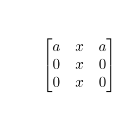

```r
texshow(B)
```

You can also provide a string instead:

```r
texshow(paste0("B = ", tex(B)))
```

giving

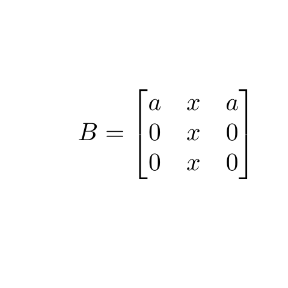

```r
texshow(paste0("B = ", tex(B)))
```

## Using `SymPy` directly

```r
sympy <- get_sympy()
```

```r
sympy$diff("2*a*x", "x")
```

```
#> 2*a
```

```r
sympy$solve("x**2 - 1", "x")
```

```
#> [[1]]
#> -1
#>
#> [[2]]
#> 1
```

## Assumptions

Below we give a brief example of assumptions. First consider the Cholesky decomposition of a matrix:

```r
A <- matrix(c("x+1", 1, 1, 1), 2, 2) %>% as_sym()
A
```

```
#> c: ⎡x + 1  1⎤
#>    ⎢        ⎥
#>    ⎣  1    1⎦
```

```r
do_la(A, "cholesky")
```

```
#> Matrix must be Hermitian.
```

This fails as `A` is not positive (semi-)definite.

To ensure this, we need to impose restrictions on `x`. This is done by defining a symbol with an assumption about positivity:

```r
y <- symbol("y", positive = TRUE)
```

We continue and define `B`, where it is important that `declare_symbols = FALSE` or else a new `y` will automatically be defined by `caracas` overwriting the above definition:

```r
B <- as_sym("[[y + 1, 1], [1, 1]]", declare_symbols = FALSE)
B
```

```
#> c: ⎡y + 1  1⎤
#>    ⎢        ⎥
#>    ⎣  1    1⎦
```

```r
do_la(B, "cholesky")
```

```
#> c: ⎡  _______                 ⎤
#>    ⎢╲╱ y + 1          0       ⎥
#>    ⎢                          ⎥
#>    ⎢               ___________⎥
#>    ⎢    1         ╱       1   ⎥
#>    ⎢─────────    ╱  1 - ───── ⎥
#>    ⎢  _______  ╲╱       y + 1 ⎥
#>    ⎣╲╱ y + 1                  ⎦
```

It is possible to ask for properties (see https://docs.sympy.org/latest/modules/assumptions/ask.html):

```r
ask(y, "positive")
```

```
#> [1] TRUE
```

```r
ask(B, "hermitian")
```

```
#> [1] TRUE
```

```r
ask(A, "hermitian")
```

```
#> [1] NA
```

## Output

```r
# Multinomial likelihood
p <- as_sym(paste0("p", 1:3))
y <- as_sym(paste0("y", 1:3))
a <- as_sym("a")
l <- sum(y*log(p))
L <- -l + a*(sum(p) - 1)
L
```

```
#> c: a⋅(p₁ + p₂ + p₃ - 1) - y₁⋅log(p₁) - y₂⋅log(p₂) - y₃⋅log(p₃)
```

```r
print(L, ascii = TRUE)
```

[output not shown]

```r
g <- der(L, list(p, a))
sol <- solve_sys(g, list(p, a))
sol
```

```
#> Solution 1:
#>   a  =  y₁ + y₂ + y₃
#>   p1 =       y₁
#>        ────────────
#>        y₁ + y₂ + y₃
#>   p2 =       y₂
#>        ────────────
#>        y₁ + y₂ + y₃
#>   p3 =       y₃
#>        ────────────
#>        y₁ + y₂ + y₃
```

```r
print(sol, simplify = FALSE)
```

```
#> [[1]]
#> [[1]]$a
#> c: y₁ + y₂ + y₃
#>
#> [[1]]$p1
#> c:      y₁
#>    ────────────
#>    y₁ + y₂ + y₃
#>
#> [[1]]$p2
#> c:      y₂
#>    ────────────
#>    y₁ + y₂ + y₃
#>
#> [[1]]$p3
#> c:      y₃
#>    ────────────
#>    y₁ + y₂ + y₃
```

```r
as.character(g)
```

```
#> [1] "[a - y1/p1, a - y2/p2, a - y3/p3, p1 + p2 + p3 - 1]"
```

```r
as_character_matrix(g)
```

```
#>      [,1]        [,2]        [,3]        [,4]
#> [1,] "a - y1/p1" "a - y2/p2" "a - y3/p3" "p1 + p2 + p3 - 1"
```

### Options

The following options are available:

- `caracas.print.method` (`utf8` is default, others are: `prettyascii`, `ascii`, `compactascii`)
- `caracas.print.rowvec`
- `caracas.print.sol.simplify`

```r
sol
```

```
#> Solution 1:
#>   a  =  y₁ + y₂ + y₃
#>   p1 =       y₁
#>        ────────────
#>        y₁ + y₂ + y₃
#>   p2 =       y₂
#>        ────────────
#>        y₁ + y₂ + y₃
#>   p3 =       y₃
#>        ────────────
#>        y₁ + y₂ + y₃
```

```r
L
```

```
#> c: a⋅(p₁ + p₂ + p₃ - 1) - y₁⋅log(p₁) - y₂⋅log(p₂) - y₃⋅log(p₃)
```

```r
options(caracas.print.method = "prettyascii")
sol
```

```
#> Solution 1:
#>   a  =  y1 + y2 + y3
#>   p1 =       y1
#>        ------------
#>        y1 + y2 + y3
#>   p2 =       y2
#>        ------------
#>        y1 + y2 + y3
#>   p3 =       y3
#>        ------------
#>        y1 + y2 + y3
```

```r
L
```

```
#> c: a*(p1 + p2 + p3 - 1) - y1*log(p1) - y2*log(p2) - y3*log(p3)
```

```r
options(caracas.print.method = "ascii")
sol
```

```
#> Solution 1:
#>   a  =  y1 + y2 + y3
#>   p1 =  y1/(y1 + y2 + y3)
#>   p2 =  y2/(y1 + y2 + y3)
#>   p3 =  y3/(y1 + y2 + y3)
```

```r
L
```

```
#> c: a*(p1 + p2 + p3 - 1) - y1*log(p1) - y2*log(p2) - y3*log(p3)
```

```r
options(caracas.print.method = NULL) # Or 'utf8'
sol
```

```
#> Solution 1:
#>   a  =  y₁ + y₂ + y₃
#>   p1 =       y₁
#>        ────────────
#>        y₁ + y₂ + y₃
#>   p2 =       y₂
#>        ────────────
#>        y₁ + y₂ + y₃
#>   p3 =       y₃
#>        ────────────
#>        y₁ + y₂ + y₃
```

```r
L
```

```
#> c: a⋅(p₁ + p₂ + p₃ - 1) - y₁⋅log(p₁) - y₂⋅log(p₂) - y₃⋅log(p₃)
```

```r
p
```

```
#> c: [p₁  p₂  p₃]ᵀ
```

```r
options(caracas.print.rowvec = FALSE)
p
```

```
#> c: ⎡p₁⎤
#>    ⎢  ⎥
#>    ⎢p₂⎥
#>    ⎢  ⎥
#>    ⎣p₃⎦
```

```r
options(caracas.print.rowvec = NULL) # reset to default (TRUE)
```

```r
sol
```

```
#> Solution 1:
#>   a  =  y₁ + y₂ + y₃
#>   p1 =       y₁
#>        ────────────
#>        y₁ + y₂ + y₃
#>   p2 =       y₂
#>        ────────────
#>        y₁ + y₂ + y₃
#>   p3 =       y₃
#>        ────────────
#>        y₁ + y₂ + y₃
```

```r
options(caracas.print.sol.simplify = FALSE)
sol
```

```
#> [[1]]
#> [[1]]$a
#> c: y₁ + y₂ + y₃
#>
#> [[1]]$p1
#> c:      y₁
#>    ────────────
#>    y₁ + y₂ + y₃
#>
#> [[1]]$p2
#> c:      y₂
#>    ────────────
#>    y₁ + y₂ + y₃
#>
#> [[1]]$p3
#> c:      y₃
#>    ────────────
#>    y₁ + y₂ + y₃
```

```r
options(caracas.print.sol.simplify = NULL) # reset to default (TRUE)
```